# Risk Factor Analysis

## Outcome Variable

**Outcome Variable:** ever_stunted

## Predictor Variables

**Intervention Variable:** nrooms

**Adjustment Set:**

unadjusted

## Stratifying Variables

The analysis was stratified on these variable(s):

- agecat
- studyid
- country

## Data Summary

| agecat | studyid | country | nrooms | ever_stunted | n_cell | n |
| --- | --- | --- | --- | --- | --- | --- |
| 0-24 months | ki0047075b-MAL-ED | BANGLADESH | 1 | 0 | 56 | 242 |
| 0-24 months | ki0047075b-MAL-ED | BANGLADESH | 1 | 1 | 96 | 242 |
| 0-24 months | ki0047075b-MAL-ED | BANGLADESH | 2 | 0 | 19 | 242 |
| 0-24 months | ki0047075b-MAL-ED | BANGLADESH | 2 | 1 | 31 | 242 |
| 0-24 months | ki0047075b-MAL-ED | BANGLADESH | 3 | 0 | 11 | 242 |
| 0-24 months | ki0047075b-MAL-ED | BANGLADESH | 3 | 1 | 17 | 242 |
| 0-24 months | ki0047075b-MAL-ED | BANGLADESH | 4+ | 0 | 8 | 242 |
| 0-24 months | ki0047075b-MAL-ED | BANGLADESH | 4+ | 1 | 4 | 242 |
| 0-24 months | ki0047075b-MAL-ED | BRAZIL | 1 | 0 | 4 | 210 |
| 0-24 months | ki0047075b-MAL-ED | BRAZIL | 1 | 1 | 0 | 210 |
| 0-24 months | ki0047075b-MAL-ED | BRAZIL | 2 | 0 | 16 | 210 |
| 0-24 months | ki0047075b-MAL-ED | BRAZIL | 2 | 1 | 4 | 210 |
| 0-24 months | ki0047075b-MAL-ED | BRAZIL | 3 | 0 | 42 | 210 |
| 0-24 months | ki0047075b-MAL-ED | BRAZIL | 3 | 1 | 17 | 210 |
| 0-24 months | ki0047075b-MAL-ED | BRAZIL | 4+ | 0 | 99 | 210 |
| 0-24 months | ki0047075b-MAL-ED | BRAZIL | 4+ | 1 | 28 | 210 |
| 0-24 months | ki0047075b-MAL-ED | INDIA | 1 | 0 | 39 | 235 |
| 0-24 months | ki0047075b-MAL-ED | INDIA | 1 | 1 | 45 | 235 |
| 0-24 months | ki0047075b-MAL-ED | INDIA | 2 | 0 | 21 | 235 |
| 0-24 months | ki0047075b-MAL-ED | INDIA | 2 | 1 | 57 | 235 |
| 0-24 months | ki0047075b-MAL-ED | INDIA | 3 | 0 | 22 | 235 |
| 0-24 months | ki0047075b-MAL-ED | INDIA | 3 | 1 | 26 | 235 |
| 0-24 months | ki0047075b-MAL-ED | INDIA | 4+ | 0 | 9 | 235 |
| 0-24 months | ki0047075b-MAL-ED | INDIA | 4+ | 1 | 16 | 235 |
| 0-24 months | ki0047075b-MAL-ED | NEPAL | 1 | 0 | 33 | 236 |
| 0-24 months | ki0047075b-MAL-ED | NEPAL | 1 | 1 | 19 | 236 |
| 0-24 months | ki0047075b-MAL-ED | NEPAL | 2 | 0 | 22 | 236 |
| 0-24 months | ki0047075b-MAL-ED | NEPAL | 2 | 1 | 9 | 236 |
| 0-24 months | ki0047075b-MAL-ED | NEPAL | 3 | 0 | 12 | 236 |
| 0-24 months | ki0047075b-MAL-ED | NEPAL | 3 | 1 | 10 | 236 |

[output cut: 354 more lines]

The following strata were considered:

- agecat: 0-24 months, studyid: ki0047075b-MAL-ED, country: BANGLADESH
- agecat: 0-24 months, studyid: ki0047075b-MAL-ED, country: BRAZIL
- agecat: 0-24 months, studyid: ki0047075b-MAL-ED, country: INDIA
- agecat: 0-24 months, studyid: ki0047075b-MAL-ED, country: NEPAL
- agecat: 0-24 months, studyid: ki0047075b-MAL-ED, country: PERU
- agecat: 0-24 months, studyid: ki0047075b-MAL-ED, country: SOUTH AFRICA
- agecat: 0-24 months, studyid: ki0047075b-MAL-ED, country: TANZANIA, UNITED REPUBLIC OF
- agecat: 0-24 months, studyid: ki1000108-CMC-V-BCS-2002, country: INDIA
- agecat: 0-24 months, studyid: ki1000108-IRC, country: INDIA
- agecat: 0-24 months, studyid: ki1017093b-PROVIDE, country: BANGLADESH
- agecat: 0-24 months, studyid: ki1017093c-NIH-Crypto, country: BANGLADESH
- agecat: 0-24 months, studyid: ki1113344-GMS-Nepal, country: NEPAL
- agecat: 0-24 months, studyid: ki1114097-CONTENT, country: PERU
- agecat: 0-24 months, studyid: ki1135781-COHORTS, country: INDIA
- agecat: 0-24 months, studyid: kiGH5241-JiVitA-3, country: BANGLADESH
- agecat: 0-24 months, studyid: kiGH5241-JiVitA-4, country: BANGLADESH
- agecat: 0-6 months, studyid: ki0047075b-MAL-ED, country: BANGLADESH
- agecat: 0-6 months, studyid: ki0047075b-MAL-ED, country: BRAZIL
- agecat: 0-6 months, studyid: ki0047075b-MAL-ED, country: INDIA
- agecat: 0-6 months, studyid: ki0047075b-MAL-ED, country: NEPAL
- agecat: 0-6 months, studyid: ki0047075b-MAL-ED, country: PERU
- agecat: 0-6 months, studyid: ki0047075b-MAL-ED, country: SOUTH AFRICA
- agecat: 0-6 months, studyid: ki0047075b-MAL-ED, country: TANZANIA, UNITED REPUBLIC OF
- agecat: 0-6 months, studyid: ki1000108-CMC-V-BCS-2002, country: INDIA
- agecat: 0-6 months, studyid: ki1000108-IRC, country: INDIA
- agecat: 0-6 months, studyid: ki1017093b-PROVIDE, country: BANGLADESH
- agecat: 0-6 months, studyid: ki1017093c-NIH-Crypto, country: BANGLADESH
- agecat: 0-6 months, studyid: ki1113344-GMS-Nepal, country: NEPAL
- agecat: 0-6 months, studyid: ki1114097-CONTENT, country: PERU
- agecat: 0-6 months, studyid: ki1135781-COHORTS, country: INDIA
- agecat: 0-6 months, studyid: kiGH5241-JiVitA-3, country: BANGLADESH
- agecat: 0-6 months, studyid: kiGH5241-JiVitA-4, country: BANGLADESH
- agecat: 6-24 months, studyid: ki0047075b-MAL-ED, country: BANGLADESH
- agecat: 6-24 months, studyid: ki0047075b-MAL-ED, country: BRAZIL
- agecat: 6-24 months, studyid: ki0047075b-MAL-ED, country: INDIA
- agecat: 6-24 months, studyid: ki0047075b-MAL-ED, country: NEPAL
- agecat: 6-24 months, studyid: ki0047075b-MAL-ED, country: PERU
- agecat: 6-24 months, studyid: ki0047075b-MAL-ED, country: SOUTH AFRICA
- agecat: 6-24 months, studyid: ki0047075b-MAL-ED, country: TANZANIA, UNITED REPUBLIC OF
- agecat: 6-24 months, studyid: ki1000108-CMC-V-BCS-2002, country: INDIA
- agecat: 6-24 months, studyid: ki1000108-IRC, country: INDIA
- agecat: 6-24 months, studyid: ki1017093b-PROVIDE, country: BANGLADESH
- agecat: 6-24 months, studyid: ki1017093c-NIH-Crypto, country: BANGLADESH
- agecat: 6-24 months, studyid: ki1113344-GMS-Nepal, country: NEPAL
- agecat: 6-24 months, studyid: ki1114097-CONTENT, country: PERU
- agecat: 6-24 months, studyid: ki1135781-COHORTS, country: INDIA
- agecat: 6-24 months, studyid: kiGH5241-JiVitA-3, country: BANGLADESH
- agecat: 6-24 months, studyid: kiGH5241-JiVitA-4, country: BANGLADESH

### Dropped Strata

Some strata were dropped due to rare outcomes:

- agecat: 0-24 months, studyid: ki0047075b-MAL-ED, country: BANGLADESH
- agecat: 0-24 months, studyid: ki0047075b-MAL-ED, country: BRAZIL
- agecat: 0-24 months, studyid: ki0047075b-MAL-ED, country: PERU
- agecat: 0-24 months, studyid: ki1000108-CMC-V-BCS-2002, country: INDIA
- agecat: 0-24 months, studyid: ki1000108-IRC, country: INDIA
- agecat: 0-6 months, studyid: ki0047075b-MAL-ED, country: BANGLADESH
- agecat: 0-6 months, studyid: ki0047075b-MAL-ED, country: BRAZIL
- agecat: 0-6 months, studyid: ki0047075b-MAL-ED, country: NEPAL
- agecat: 0-6 months, studyid: ki1017093b-PROVIDE, country: BANGLADESH
- agecat: 6-24 months, studyid: ki0047075b-MAL-ED, country: BANGLADESH
- agecat: 6-24 months, studyid: ki0047075b-MAL-ED, country: BRAZIL
- agecat: 6-24 months, studyid: ki0047075b-MAL-ED, country: NEPAL
- agecat: 6-24 months, studyid: ki0047075b-MAL-ED, country: PERU
- agecat: 6-24 months, studyid: ki0047075b-MAL-ED, country: SOUTH AFRICA
- agecat: 6-24 months, studyid: ki0047075b-MAL-ED, country: TANZANIA, UNITED REPUBLIC OF
- agecat: 6-24 months, studyid: ki1000108-CMC-V-BCS-2002, country: INDIA
- agecat: 6-24 months, studyid: ki1000108-IRC, country: INDIA
- agecat: 6-24 months, studyid: ki1017093b-PROVIDE, country: BANGLADESH
- agecat: 6-24 months, studyid: ki1114097-CONTENT, country: PERU

## Methods Detail

We’re interested in the causal parameters $E[Y_a]$ for all values of $a \in \mathcal{A}$. These parameters represent the mean outcome if, possibly contrary to fact, we intervened to set all units to have $A=a$. Under the randomization and positivity assumptions, these are identified by the statistical parameters $\psi_a=E_W[E_{Y|A,W}(Y|A=a,W)]$. In addition, we’re interested in the mean of $Y$, $E[Y]$ under no intervention (the observed mean). We will estimate these parameters by using SuperLearner to fit the relevant likelihood factors – $E_{Y|A,W}(Y|A=a,W)$ and $p(A=a|W)$, and then updating our likelihood fit using a joint TMLE.

For unadjusted analyses ($W=\{\}$), initial likelihoods were estimated using Lrnr_glm to estimate the simple $E(Y|A)$ and Lrnr_mean to estimate $p(A)$. For adjusted analyses, a small library containing Lrnr_glmnet, Lrnr_xgboost, and Lrnr_mean was used.

Having estimated these parameters, we will then use the delta method to estimate relative risks and attributable risks relative to a prespecified baseline level of $A$.

# Results Detail

## Results Plots

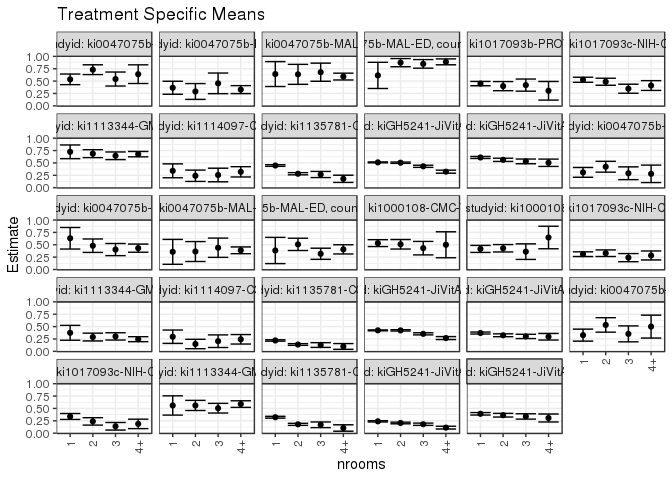

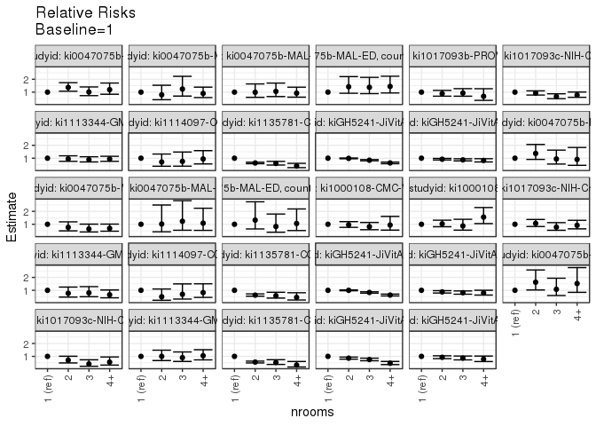

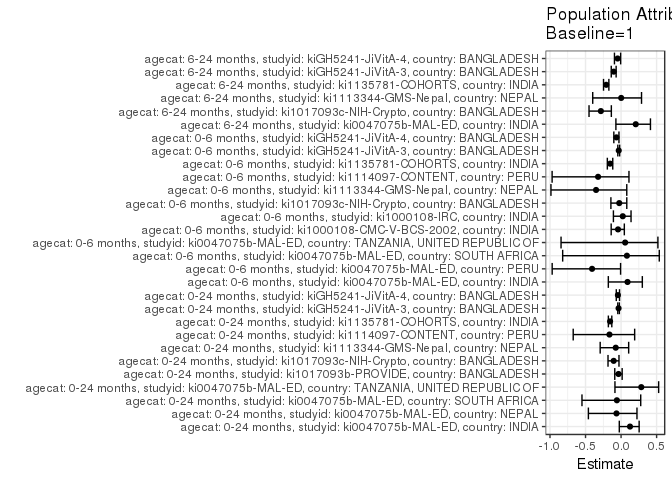

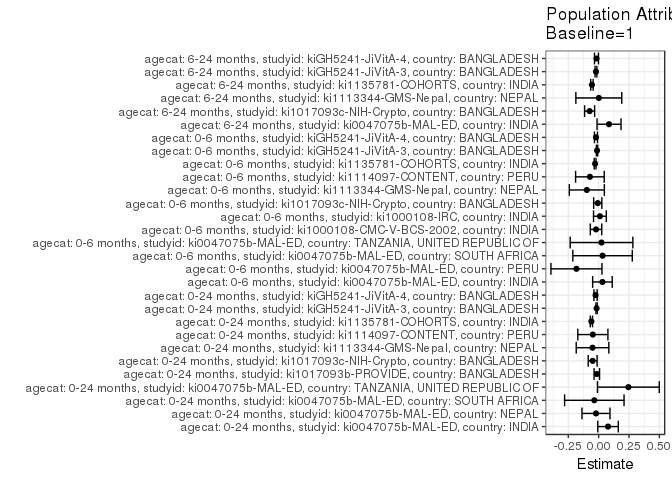

## Results Table

### Parameter: TSM

| agecat | studyid | country | intervention_level | baseline_level | estimate | ci_lower | ci_upper |
| --- | --- | --- | --- | --- | --- | --- | --- |
| 0-24 months | ki0047075b-MAL-ED | INDIA | 1 | NA | 0.5357143 | 0.4288350 | 0.6425936 |
| 0-24 months | ki0047075b-MAL-ED | INDIA | 2 | NA | 0.7307692 | 0.6321233 | 0.8294152 |
| 0-24 months | ki0047075b-MAL-ED | INDIA | 3 | NA | 0.5416667 | 0.4004096 | 0.6829238 |
| 0-24 months | ki0047075b-MAL-ED | INDIA | 4+ | NA | 0.6400000 | 0.4514418 | 0.8285582 |
| 0-24 months | ki0047075b-MAL-ED | NEPAL | 1 | NA | 0.3653846 | 0.2342254 | 0.4965439 |
| 0-24 months | ki0047075b-MAL-ED | NEPAL | 2 | NA | 0.2903226 | 0.1301972 | 0.4504480 |
| 0-24 months | ki0047075b-MAL-ED | NEPAL | 3 | NA | 0.4545455 | 0.2460355 | 0.6630554 |
| 0-24 months | ki0047075b-MAL-ED | NEPAL | 4+ | NA | 0.3282443 | 0.2476621 | 0.4088264 |
| 0-24 months | ki0047075b-MAL-ED | SOUTH AFRICA | 1 | NA | 0.6428571 | 0.3913740 | 0.8943403 |
| 0-24 months | ki0047075b-MAL-ED | SOUTH AFRICA | 2 | NA | 0.6363636 | 0.4349589 | 0.8377684 |
| 0-24 months | ki0047075b-MAL-ED | SOUTH AFRICA | 3 | NA | 0.6800000 | 0.4967879 | 0.8632121 |
| 0-24 months | ki0047075b-MAL-ED | SOUTH AFRICA | 4+ | NA | 0.5918367 | 0.5228946 | 0.6607788 |
| 0-24 months | ki0047075b-MAL-ED | TANZANIA, UNITED REPUBLIC OF | 1 | NA | 0.6153846 | 0.3503922 | 0.8803770 |
| 0-24 months | ki0047075b-MAL-ED | TANZANIA, UNITED REPUBLIC OF | 2 | NA | 0.8730159 | 0.7906336 | 0.9553982 |
| 0-24 months | ki0047075b-MAL-ED | TANZANIA, UNITED REPUBLIC OF | 3 | NA | 0.8484848 | 0.7618093 | 0.9351604 |
| 0-24 months | ki0047075b-MAL-ED | TANZANIA, UNITED REPUBLIC OF | 4+ | NA | 0.8888889 | 0.8294995 | 0.9482783 |
| 0-24 months | ki1017093b-PROVIDE | BANGLADESH | 1 | NA | 0.4497041 | 0.4063714 | 0.4930369 |
| 0-24 months | ki1017093b-PROVIDE | BANGLADESH | 2 | NA | 0.3981481 | 0.3057605 | 0.4905358 |
| 0-24 months | ki1017093b-PROVIDE | BANGLADESH | 3 | NA | 0.4193548 | 0.2964387 | 0.5422710 |
| 0-24 months | ki1017093b-PROVIDE | BANGLADESH | 4+ | NA | 0.3043478 | 0.1161668 | 0.4925288 |
| 0-24 months | ki1017093c-NIH-Crypto | BANGLADESH | 1 | NA | 0.5271739 | 0.4761306 | 0.5782172 |
| 0-24 months | ki1017093c-NIH-Crypto | BANGLADESH | 2 | NA | 0.4869110 | 0.4159795 | 0.5578425 |
| 0-24 months | ki1017093c-NIH-Crypto | BANGLADESH | 3 | NA | 0.3461538 | 0.2546603 | 0.4376474 |
| 0-24 months | ki1017093c-NIH-Crypto | BANGLADESH | 4+ | NA | 0.4105263 | 0.3115399 | 0.5095127 |
| 0-24 months | ki1113344-GMS-Nepal | NEPAL | 1 | NA | 0.7250000 | 0.5865113 | 0.8634887 |
| 0-24 months | ki1113344-GMS-Nepal | NEPAL | 2 | NA | 0.6875000 | 0.6071353 | 0.7678647 |
| 0-24 months | ki1113344-GMS-Nepal | NEPAL | 3 | NA | 0.6442953 | 0.5673640 | 0.7212266 |
| 0-24 months | ki1113344-GMS-Nepal | NEPAL | 4+ | NA | 0.6771930 | 0.6228662 | 0.7315198 |
| 0-24 months | ki1114097-CONTENT | PERU | 1 | NA | 0.3409091 | 0.2005224 | 0.4812958 |
| 0-24 months | ki1114097-CONTENT | PERU | 2 | NA | 0.2407407 | 0.1264441 | 0.3550374 |

[output cut: 86 more lines]

### Parameter: E(Y)

| agecat | studyid | country | intervention_level | baseline_level | estimate | ci_lower | ci_upper |
| --- | --- | --- | --- | --- | --- | --- | --- |
| 0-24 months | ki0047075b-MAL-ED | INDIA | NA | NA | 0.6127660 | 0.5503531 | 0.6751788 |
| 0-24 months | ki0047075b-MAL-ED | NEPAL | NA | NA | 0.3432203 | 0.2825173 | 0.4039234 |
| 0-24 months | ki0047075b-MAL-ED | SOUTH AFRICA | NA | NA | 0.6070039 | 0.5471740 | 0.6668337 |
| 0-24 months | ki0047075b-MAL-ED | TANZANIA, UNITED REPUBLIC OF | NA | NA | 0.8600000 | 0.8169015 | 0.9030985 |
| 0-24 months | ki1017093b-PROVIDE | BANGLADESH | NA | NA | 0.4342857 | 0.3975409 | 0.4710305 |
| 0-24 months | ki1017093c-NIH-Crypto | BANGLADESH | NA | NA | 0.4775726 | 0.4419904 | 0.5131548 |
| 0-24 months | ki1113344-GMS-Nepal | NEPAL | NA | NA | 0.6744186 | 0.6369554 | 0.7118819 |
| 0-24 months | ki1114097-CONTENT | PERU | NA | NA | 0.2930233 | 0.2320422 | 0.3540043 |
| 0-24 months | ki1135781-COHORTS | INDIA | NA | NA | 0.3879792 | 0.3749497 | 0.4010086 |
| 0-24 months | kiGH5241-JiVitA-3 | BANGLADESH | NA | NA | 0.4941218 | 0.4862726 | 0.5019709 |
| 0-24 months | kiGH5241-JiVitA-4 | BANGLADESH | NA | NA | 0.5844710 | 0.5684819 | 0.6004601 |
| 0-6 months | ki0047075b-MAL-ED | INDIA | NA | NA | 0.3404255 | 0.2797123 | 0.4011387 |
| 0-6 months | ki0047075b-MAL-ED | PERU | NA | NA | 0.4485294 | 0.3893160 | 0.5077428 |
| 0-6 months | ki0047075b-MAL-ED | SOUTH AFRICA | NA | NA | 0.3891051 | 0.3293816 | 0.4488285 |
| 0-6 months | ki0047075b-MAL-ED | TANZANIA, UNITED REPUBLIC OF | NA | NA | 0.4080000 | 0.3469565 | 0.4690435 |
| 0-6 months | ki1000108-CMC-V-BCS-2002 | INDIA | NA | NA | 0.5108696 | 0.4597270 | 0.5620121 |
| 0-6 months | ki1000108-IRC | INDIA | NA | NA | 0.4264706 | 0.3784228 | 0.4745184 |
| 0-6 months | ki1017093c-NIH-Crypto | BANGLADESH | NA | NA | 0.3021108 | 0.2694011 | 0.3348205 |
| 0-6 months | ki1113344-GMS-Nepal | NEPAL | NA | NA | 0.2774086 | 0.2416141 | 0.3132032 |
| 0-6 months | ki1114097-CONTENT | PERU | NA | NA | 0.2232558 | 0.1674626 | 0.2790491 |
| 0-6 months | ki1135781-COHORTS | INDIA | NA | NA | 0.1906412 | 0.1799566 | 0.2013259 |
| 0-6 months | kiGH5241-JiVitA-3 | BANGLADESH | NA | NA | 0.4109064 | 0.4034556 | 0.4183572 |
| 0-6 months | kiGH5241-JiVitA-4 | BANGLADESH | NA | NA | 0.3474692 | 0.3322601 | 0.3626783 |
| 6-24 months | ki0047075b-MAL-ED | INDIA | NA | NA | 0.4129032 | 0.3351414 | 0.4906651 |
| 6-24 months | ki1017093c-NIH-Crypto | BANGLADESH | NA | NA | 0.2628458 | 0.2244546 | 0.3012371 |
| 6-24 months | ki1113344-GMS-Nepal | NEPAL | NA | NA | 0.5610329 | 0.5138522 | 0.6082135 |
| 6-24 months | ki1135781-COHORTS | INDIA | NA | NA | 0.2665531 | 0.2530304 | 0.2800757 |
| 6-24 months | kiGH5241-JiVitA-3 | BANGLADESH | NA | NA | 0.2170266 | 0.2076700 | 0.2263831 |
| 6-24 months | kiGH5241-JiVitA-4 | BANGLADESH | NA | NA | 0.3735682 | 0.3548662 | 0.3922701 |

### Parameter: RR

| agecat | studyid | country | intervention_level | baseline_level | estimate | ci_lower | ci_upper |
| --- | --- | --- | --- | --- | --- | --- | --- |
| 0-24 months | ki0047075b-MAL-ED | INDIA | 1 | 1 | 1.0000000 | 1.0000000 | 1.0000000 |
| 0-24 months | ki0047075b-MAL-ED | INDIA | 2 | 1 | 1.3641026 | 1.0720919 | 1.7356495 |
| 0-24 months | ki0047075b-MAL-ED | INDIA | 3 | 1 | 1.0111111 | 0.7281153 | 1.4040986 |
| 0-24 months | ki0047075b-MAL-ED | INDIA | 4+ | 1 | 1.1946667 | 0.8369845 | 1.7052029 |
| 0-24 months | ki0047075b-MAL-ED | NEPAL | 1 | 1 | 1.0000000 | 1.0000000 | 1.0000000 |
| 0-24 months | ki0047075b-MAL-ED | NEPAL | 2 | 1 | 0.7945671 | 0.4114672 | 1.5343551 |
| 0-24 months | ki0047075b-MAL-ED | NEPAL | 3 | 1 | 1.2440191 | 0.6948011 | 2.2273766 |
| 0-24 months | ki0047075b-MAL-ED | NEPAL | 4+ | 1 | 0.8983528 | 0.5815413 | 1.3877564 |
| 0-24 months | ki0047075b-MAL-ED | SOUTH AFRICA | 1 | 1 | 1.0000000 | 1.0000000 | 1.0000000 |
| 0-24 months | ki0047075b-MAL-ED | SOUTH AFRICA | 2 | 1 | 0.9898990 | 0.5984906 | 1.6372854 |
| 0-24 months | ki0047075b-MAL-ED | SOUTH AFRICA | 3 | 1 | 1.0577778 | 0.6578151 | 1.7009245 |
| 0-24 months | ki0047075b-MAL-ED | SOUTH AFRICA | 4+ | 1 | 0.9206349 | 0.6120979 | 1.3846946 |
| 0-24 months | ki0047075b-MAL-ED | TANZANIA, UNITED REPUBLIC OF | 1 | 1 | 1.0000000 | 1.0000000 | 1.0000000 |
| 0-24 months | ki0047075b-MAL-ED | TANZANIA, UNITED REPUBLIC OF | 2 | 1 | 1.4186508 | 0.9129038 | 2.2045807 |
| 0-24 months | ki0047075b-MAL-ED | TANZANIA, UNITED REPUBLIC OF | 3 | 1 | 1.3787879 | 0.8857161 | 2.1463492 |
| 0-24 months | ki0047075b-MAL-ED | TANZANIA, UNITED REPUBLIC OF | 4+ | 1 | 1.4444444 | 0.9342228 | 2.2333214 |
| 0-24 months | ki1017093b-PROVIDE | BANGLADESH | 1 | 1 | 1.0000000 | 1.0000000 | 1.0000000 |
| 0-24 months | ki1017093b-PROVIDE | BANGLADESH | 2 | 1 | 0.8853558 | 0.6886510 | 1.1382468 |
| 0-24 months | ki1017093b-PROVIDE | BANGLADESH | 3 | 1 | 0.9325127 | 0.6849478 | 1.2695566 |
| 0-24 months | ki1017093b-PROVIDE | BANGLADESH | 4+ | 1 | 0.6767735 | 0.3619711 | 1.2653561 |
| 0-24 months | ki1017093c-NIH-Crypto | BANGLADESH | 1 | 1 | 1.0000000 | 1.0000000 | 1.0000000 |
| 0-24 months | ki1017093c-NIH-Crypto | BANGLADESH | 2 | 1 | 0.9236250 | 0.7754064 | 1.1001755 |
| 0-24 months | ki1017093c-NIH-Crypto | BANGLADESH | 3 | 1 | 0.6566217 | 0.4955246 | 0.8700922 |
| 0-24 months | ki1017093c-NIH-Crypto | BANGLADESH | 4+ | 1 | 0.7787303 | 0.6005404 | 1.0097921 |
| 0-24 months | ki1113344-GMS-Nepal | NEPAL | 1 | 1 | 1.0000000 | 1.0000000 | 1.0000000 |
| 0-24 months | ki1113344-GMS-Nepal | NEPAL | 2 | 1 | 0.9482759 | 0.7580110 | 1.1862982 |
| 0-24 months | ki1113344-GMS-Nepal | NEPAL | 3 | 1 | 0.8886832 | 0.7094380 | 1.1132160 |
| 0-24 months | ki1113344-GMS-Nepal | NEPAL | 4+ | 1 | 0.9340593 | 0.7592709 | 1.1490849 |
| 0-24 months | ki1114097-CONTENT | PERU | 1 | 1 | 1.0000000 | 1.0000000 | 1.0000000 |
| 0-24 months | ki1114097-CONTENT | PERU | 2 | 1 | 0.7061728 | 0.3766739 | 1.3239039 |

[output cut: 86 more lines]

### Parameter: PAR

| agecat | studyid | country | intervention_level | baseline_level | estimate | ci_lower | ci_upper |
| --- | --- | --- | --- | --- | --- | --- | --- |
| 0-24 months | ki0047075b-MAL-ED | INDIA | 1 | NA | 0.0770517 | -0.0075190 | 0.1616223 |
| 0-24 months | ki0047075b-MAL-ED | NEPAL | 1 | NA | -0.0221643 | -0.1375191 | 0.0931906 |
| 0-24 months | ki0047075b-MAL-ED | SOUTH AFRICA | 1 | NA | -0.0358533 | -0.2806654 | 0.2089589 |
| 0-24 months | ki0047075b-MAL-ED | TANZANIA, UNITED REPUBLIC OF | 1 | NA | 0.2446154 | -0.0098948 | 0.4991256 |
| 0-24 months | ki1017093b-PROVIDE | BANGLADESH | 1 | NA | -0.0154184 | -0.0379548 | 0.0071179 |
| 0-24 months | ki1017093c-NIH-Crypto | BANGLADESH | 1 | NA | -0.0496014 | -0.0862307 | -0.0129720 |
| 0-24 months | ki1113344-GMS-Nepal | NEPAL | 1 | NA | -0.0505814 | -0.1848718 | 0.0837090 |
| 0-24 months | ki1114097-CONTENT | PERU | 1 | NA | -0.0478858 | -0.1718230 | 0.0760513 |
| 0-24 months | ki1135781-COHORTS | INDIA | 1 | NA | -0.0598753 | -0.0691580 | -0.0505927 |
| 0-24 months | kiGH5241-JiVitA-3 | BANGLADESH | 1 | NA | -0.0173568 | -0.0227449 | -0.0119687 |
| 0-24 months | kiGH5241-JiVitA-4 | BANGLADESH | 1 | NA | -0.0258977 | -0.0391378 | -0.0126577 |
| 0-6 months | ki0047075b-MAL-ED | INDIA | 1 | NA | 0.0309017 | -0.0496250 | 0.1114284 |
| 0-6 months | ki0047075b-MAL-ED | PERU | 1 | NA | -0.1830495 | -0.3931167 | 0.0270176 |
| 0-6 months | ki0047075b-MAL-ED | SOUTH AFRICA | 1 | NA | 0.0319622 | -0.2128240 | 0.2767484 |
| 0-6 months | ki0047075b-MAL-ED | TANZANIA, UNITED REPUBLIC OF | 1 | NA | 0.0233846 | -0.2347709 | 0.2815402 |
| 0-6 months | ki1000108-CMC-V-BCS-2002 | INDIA | 1 | NA | -0.0217938 | -0.0689398 | 0.0253523 |
| 0-6 months | ki1000108-IRC | INDIA | 1 | NA | 0.0102544 | -0.0424681 | 0.0629768 |
| 0-6 months | ki1017093c-NIH-Crypto | BANGLADESH | 1 | NA | -0.0076718 | -0.0413584 | 0.0260149 |
| 0-6 months | ki1113344-GMS-Nepal | NEPAL | 1 | NA | -0.0975914 | -0.2419212 | 0.0467385 |
| 0-6 months | ki1114097-CONTENT | PERU | 1 | NA | -0.0721987 | -0.1900894 | 0.0456919 |
| 0-6 months | ki1135781-COHORTS | INDIA | 1 | NA | -0.0294587 | -0.0368045 | -0.0221128 |
| 0-6 months | kiGH5241-JiVitA-3 | BANGLADESH | 1 | NA | -0.0134772 | -0.0187568 | -0.0081975 |
| 0-6 months | kiGH5241-JiVitA-4 | BANGLADESH | 1 | NA | -0.0226434 | -0.0352034 | -0.0100835 |
| 6-24 months | ki0047075b-MAL-ED | INDIA | 1 | NA | 0.0853170 | -0.0133824 | 0.1840164 |
| 6-24 months | ki1017093c-NIH-Crypto | BANGLADESH | 1 | NA | -0.0747069 | -0.1159810 | -0.0334328 |
| 6-24 months | ki1113344-GMS-Nepal | NEPAL | 1 | NA | 0.0010329 | -0.1879704 | 0.1900361 |
| 6-24 months | ki1135781-COHORTS | INDIA | 1 | NA | -0.0556129 | -0.0656739 | -0.0455519 |
| 6-24 months | kiGH5241-JiVitA-3 | BANGLADESH | 1 | NA | -0.0224065 | -0.0298581 | -0.0149549 |
| 6-24 months | kiGH5241-JiVitA-4 | BANGLADESH | 1 | NA | -0.0181300 | -0.0343923 | -0.0018676 |

### Parameter: PAF

| agecat | studyid | country | intervention_level | baseline_level | estimate | ci_lower | ci_upper |
| --- | --- | --- | --- | --- | --- | --- | --- |
| 0-24 months | ki0047075b-MAL-ED | INDIA | 1 | NA | 0.1257440 | -0.0249866 | 0.2543088 |
| 0-24 months | ki0047075b-MAL-ED | NEPAL | 1 | NA | -0.0645774 | -0.4598102 | 0.2236490 |
| 0-24 months | ki0047075b-MAL-ED | SOUTH AFRICA | 1 | NA | -0.0590659 | -0.5500643 | 0.2764038 |
| 0-24 months | ki0047075b-MAL-ED | TANZANIA, UNITED REPUBLIC OF | 1 | NA | 0.2844365 | -0.0861239 | 0.5285702 |
| 0-24 months | ki1017093b-PROVIDE | BANGLADESH | 1 | NA | -0.0355030 | -0.0887720 | 0.0151598 |
| 0-24 months | ki1017093c-NIH-Crypto | BANGLADESH | 1 | NA | -0.1038614 | -0.1837130 | -0.0293965 |
| 0-24 months | ki1113344-GMS-Nepal | NEPAL | 1 | NA | -0.0750000 | -0.2939360 | 0.1068917 |
| 0-24 months | ki1114097-CONTENT | PERU | 1 | NA | -0.1634199 | -0.6734226 | 0.1911512 |
| 0-24 months | ki1135781-COHORTS | INDIA | 1 | NA | -0.1543262 | -0.1787658 | -0.1303933 |
| 0-24 months | kiGH5241-JiVitA-3 | BANGLADESH | 1 | NA | -0.0351266 | -0.0461284 | -0.0242405 |
| 0-24 months | kiGH5241-JiVitA-4 | BANGLADESH | 1 | NA | -0.0443097 | -0.0673118 | -0.0218033 |
| 0-6 months | ki0047075b-MAL-ED | INDIA | 1 | NA | 0.0907738 | -0.1793511 | 0.2990279 |
| 0-6 months | ki0047075b-MAL-ED | PERU | 1 | NA | -0.4081104 | -0.9693100 | -0.0068374 |
| 0-6 months | ki0047075b-MAL-ED | SOUTH AFRICA | 1 | NA | 0.0821429 | -0.8215926 | 0.5375136 |
| 0-6 months | ki0047075b-MAL-ED | TANZANIA, UNITED REPUBLIC OF | 1 | NA | 0.0573152 | -0.8444840 | 0.5182097 |
| 0-6 months | ki1000108-CMC-V-BCS-2002 | INDIA | 1 | NA | -0.0426601 | -0.1392805 | 0.0457661 |
| 0-6 months | ki1000108-IRC | INDIA | 1 | NA | 0.0240447 | -0.1077667 | 0.1401722 |
| 0-6 months | ki1017093c-NIH-Crypto | BANGLADESH | 1 | NA | -0.0253940 | -0.1431825 | 0.0802582 |
| 0-6 months | ki1113344-GMS-Nepal | NEPAL | 1 | NA | -0.3517964 | -0.9864905 | 0.0801096 |
| 0-6 months | ki1114097-CONTENT | PERU | 1 | NA | -0.3233902 | -0.9701145 | 0.1110357 |
| 0-6 months | ki1135781-COHORTS | INDIA | 1 | NA | -0.1545241 | -0.1932452 | -0.1170594 |
| 0-6 months | kiGH5241-JiVitA-3 | BANGLADESH | 1 | NA | -0.0327986 | -0.0457430 | -0.0200144 |
| 0-6 months | kiGH5241-JiVitA-4 | BANGLADESH | 1 | NA | -0.0651667 | -0.1018289 | -0.0297245 |
| 6-24 months | ki0047075b-MAL-ED | INDIA | 1 | NA | 0.2066272 | -0.0728229 | 0.4132858 |
| 6-24 months | ki1017093c-NIH-Crypto | BANGLADESH | 1 | NA | -0.2842232 | -0.4507323 | -0.1368254 |
| 6-24 months | ki1113344-GMS-Nepal | NEPAL | 1 | NA | 0.0018410 | -0.3988678 | 0.2877659 |
| 6-24 months | ki1135781-COHORTS | INDIA | 1 | NA | -0.2086372 | -0.2467911 | -0.1716509 |
| 6-24 months | kiGH5241-JiVitA-3 | BANGLADESH | 1 | NA | -0.1032431 | -0.1381080 | -0.0694462 |
| 6-24 months | kiGH5241-JiVitA-4 | BANGLADESH | 1 | NA | -0.0485319 | -0.0930608 | -0.0058169 |